# Retail Sales - (Exploratory Data Analysis - EDA)

Don Jeff Bilolo (original) Ankit Deshmukh (adopted in R)

2026-09-07

# Introduction

Businesses have always used data to make informed business decisions. With significant advancements in collecting, storing, analyzing, and reporting data in the last couple of decades, extracting actionable insights from large and complex datasets has never been easier. It has now become an indispensable tool for organizations seeking to gain a competitive edge. More than ever, organizations have now been able to drive informed decisions, optimize processes, and improve overall performance by leveraging analytics technology. Such organizations include large retail companies.

This report presents an exploratory data analysis (EDA) of Superstore sales data, a fictitious retail company that closely resembles the operational characteristics of real-world retailers. The analysis aims to uncover valuable patterns, trends, and insights that can help the company better understand its sales dynamics, customer behavior, and profitability.

# Business Question

This analysis aims to address the following key business questions:

1. **Sales Performance**: What are the overall sales trends, and how have they evolved over time? Are there any significant fluctuations that need to be addressed?
2. **Product Categories**: Which product categories contributed the most to the company’s sales? Which categories are underperforming, if any?
3. **Geographic Insights**: How does sales performance vary across the regions? Are there promising geographical regions or areas requiring improved marketing?
4. **Profitability**: Which products are more profitable and which were not? With the available data, what factors affected the company’s profit? How is the company’s profitability during the period?

This analysis also aims to discover other valuable insights about the dataset. Ultimately, this analysis intends to provide actionable insights to guide decision-making and enhance overall business performance.

# Report Structure

This report is organized as follows:

- **Data Overview** - dataset overview, dataset source, size, and initial observations
- **Data Preprocessing** - data cleaning, handling missing values, and preparation for analysis
- **Exploratory Data Analysis** - analysis: statistical summaries, visualizations, and key findings
- **Conclusion** - summary of the main insights from the analysis
- **Recommendations** - recommendations based on the findings
- **Reference** - references used in the report

# Key Findings

> Summarized below are the key findings from this analysis. Throughout the 4-year period from 2011 to 2014:

> **Product Categories**
> - Phones, chairs, and storage products led in sales by category, while copiers, furnishings, and fasteners performed least.
> - No clear sales pattern emerged for product sub-categories.
> - Supplies (office supplies), copiers, and appliances experienced the highest average annual sales growth, while envelopes, chairs, and machine products grew the slowest.

# Importing Libraries

We will use R libraries for data manipulation, visualization, and analysis.

```r
library(readxl)
library(dplyr)
library(tidyr)
library(lubridate)
library(ggplot2)
library(scales)
library(knitr)
```

# 1. Data Overview

The dataset used in this analysis is the Superstore - Sales data available on Kaggle (https://www.kaggle.com/datasets/ishanshrivastava28/superstore-sales). It is available in both csv and excel format. We load the “Orders” sheet from the Excel file.

```r
data <- read_excel("Superstore.xlsx", sheet = "Orders")
head(data, 3)
```

```
## # A tibble: 3 × 21
##   `Row ID` `Order ID`     `Order Date`        `Ship Date`         `Ship Mode`
##      <dbl> <chr>          <dttm>              <dttm>              <chr>
## 1        1 CA-2013-152156 2013-11-09 00:00:00 2013-11-12 00:00:00 Second Class
## 2        2 CA-2013-152156 2013-11-09 00:00:00 2013-11-12 00:00:00 Second Class
## 3        3 CA-2013-138688 2013-06-13 00:00:00 2013-06-17 00:00:00 Second Class
## # ℹ 16 more variables: `Customer ID` <chr>, `Customer Name` <chr>,
## #   Segment <chr>, Country <chr>, City <chr>, State <chr>, `Postal Code` <dbl>,
## #   Region <chr>, `Product ID` <chr>, Category <chr>, `Sub-Category` <chr>,
## #   `Product Name` <chr>, Sales <dbl>, Quantity <dbl>, Discount <dbl>,
## #   Profit <dbl>
```

The dataset contains records of successful orders. It also contains features such as the `Order Date`, `Ship Date`, `Country` and `Region` from where the customer lives/resides, product `Category`,`Quantity`, `Sales` and `Profit`.

Below are variable descriptions for each of the columns:

- `row_id`: unique row identifier
- `order_id`: unique order identifier
- `order_date`: date the order was placed
- `ship_date`: date the order was shipped
- `ship_mode`: how the order was shipped
- `customer_id`: unique customer identifier
- `customer_name`: customer name
- `segment`: segment of product
- `country`: country of customer
- `city`: city of customer
- `state`: state of customer
- `postal_code`: postal code of customer
- `region`: Superstore region represented
- `product_id`: unique product identifier
- `category`: category of product
- `sub_category`: subcategory of product
- `product_name`: name of product
- `sales`: total sales of that product in the order
- `quantity`: total units sold of that product in the order
- `discount`: percent discount applied for that product in the order
- `profit`: total profit for that product in the order (net profit, all expenses including discount)

```r
str(data)
```

```
## tibble [9,994 × 21] (S3: tbl_df/tbl/data.frame)
##  $ Row ID       : num [1:9994] 1 2 3 4 5 6 7 8 9 10 ...
##  $ Order ID     : chr [1:9994] "CA-2013-152156" "CA-2013-152156" "CA-2013-138688" "US-2012-108966" ...
##  $ Order Date   : POSIXct[1:9994], format: "2013-11-09" "2013-11-09" ...
##  $ Ship Date    : POSIXct[1:9994], format: "2013-11-12" "2013-11-12" ...
##  $ Ship Mode    : chr [1:9994] "Second Class" "Second Class" "Second Class" "Standard Class" ...
##  $ Customer ID  : chr [1:9994] "CG-12520" "CG-12520" "DV-13045" "SO-20335" ...
##  $ Customer Name: chr [1:9994] "Claire Gute" "Claire Gute" "Darrin Van Huff" "Sean O'Donnell" ...
##  $ Segment      : chr [1:9994] "Consumer" "Consumer" "Corporate" "Consumer" ...
##  $ Country      : chr [1:9994] "United States" "United States" "United States" "United States" ...
##  $ City         : chr [1:9994] "Henderson" "Henderson" "Los Angeles" "Fort Lauderdale" ...
##  $ State        : chr [1:9994] "Kentucky" "Kentucky" "California" "Florida" ...
##  $ Postal Code  : num [1:9994] 42420 42420 90036 33311 33311 ...
##  $ Region       : chr [1:9994] "South" "South" "West" "South" ...
##  $ Product ID   : chr [1:9994] "FUR-BO-10001798" "FUR-CH-10000454" "OFF-LA-10000240" "FUR-TA-10000577" ...
##  $ Category     : chr [1:9994] "Furniture" "Furniture" "Office Supplies" "Furniture" ...
##  $ Sub-Category : chr [1:9994] "Bookcases" "Chairs" "Labels" "Tables" ...
##  $ Product Name : chr [1:9994] "Bush Somerset Collection Bookcase" "Hon Deluxe Fabric Upholstered Stacking Chairs, Rounded Back" "Self-Adhesive Address Labels for Typewriters by Universal" "Bretford CR4500 Series Slim Rectangular Table" ...
##  $ Sales        : num [1:9994] 262 731.9 14.6 957.6 22.4 ...
##  $ Quantity     : num [1:9994] 2 3 2 5 2 7 4 6 3 5 ...
##  $ Discount     : num [1:9994] 0 0 0 0.45 0.2 0 0 0.2 0.2 0 ...
##  $ Profit       : num [1:9994] 41.91 219.58 6.87 -383.03 2.52 ...
```

# 2. Data Preprocessing

With the overview, the dataset will not need a lot of data cleaning. However, there are certain transformations that needs to be done to ready the data for the analysis. Specifically, the `Row ID` column and some others are not necessary for this particular analysis and will be removed. Feature engineering will also be done.

```r
# Remove Row ID and select relevant columns
data <- data %>%
  select(-`Row ID`) %>%
  select(
    `Order ID`, `Order Date`, `Ship Date`, `Ship Mode`, Segment, City, State, Region,
    Category, `Sub-Category`, `Product Name`, Sales, Quantity, Discount, Profit
  )

# Feature engineering
data <- data %>%
  mutate(
    month = month(`Order Date`),
    year = year(`Order Date`),
    year_month = floor_date(`Order Date`, "month"),
    total_discount_in_dollars = Sales * Discount,
    selling_price = Sales / Quantity,
    `(net)_profit_before_discount` = Sales * Discount + Profit,
    order_fulfillment_time = as.numeric(difftime(`Ship Date`, `Order Date`, units = "days")),
    net_profit_per_unit_sold = Profit / Quantity,
    profit_margin = (Profit / Sales) * 100,
    discounted_sales = Sales - (Sales * Discount)
  ) %>%
  rename(net_profit = Profit)

head(data, 5)
```

```
## # A tibble: 5 × 25
##   `Order ID`   `Order Date`        `Ship Date`         `Ship Mode` Segment City
##   <chr>        <dttm>              <dttm>              <chr>       <chr>   <chr>
## 1 CA-2013-152… 2013-11-09 00:00:00 2013-11-12 00:00:00 Second Cla… Consum… Hend…
## 2 CA-2013-152… 2013-11-09 00:00:00 2013-11-12 00:00:00 Second Cla… Consum… Hend…
## 3 CA-2013-138… 2013-06-13 00:00:00 2013-06-17 00:00:00 Second Cla… Corpor… Los …
## 4 US-2012-108… 2012-10-11 00:00:00 2012-10-18 00:00:00 Standard C… Consum… Fort…
## 5 US-2012-108… 2012-10-11 00:00:00 2012-10-18 00:00:00 Standard C… Consum… Fort…
## # ℹ 19 more variables: State <chr>, Region <chr>, Category <chr>,
## #   `Sub-Category` <chr>, `Product Name` <chr>, Sales <dbl>, Quantity <dbl>,
## #   Discount <dbl>, net_profit <dbl>, month <dbl>, year <dbl>,
## #   year_month <dttm>, total_discount_in_dollars <dbl>, selling_price <dbl>,
## #   `(net)_profit_before_discount` <dbl>, order_fulfillment_time <dbl>,
## #   net_profit_per_unit_sold <dbl>, profit_margin <dbl>, discounted_sales <dbl>
```

```r
str(data)
```

```
## tibble [9,994 × 25] (S3: tbl_df/tbl/data.frame)
##  $ Order ID                    : chr [1:9994] "CA-2013-152156" "CA-2013-152156" "CA-2013-138688" "US-2012-108966" ...
##  $ Order Date                  : POSIXct[1:9994], format: "2013-11-09" "2013-11-09" ...
##  $ Ship Date                   : POSIXct[1:9994], format: "2013-11-12" "2013-11-12" ...
##  $ Ship Mode                   : chr [1:9994] "Second Class" "Second Class" "Second Class" "Standard Class" ...
##  $ Segment                     : chr [1:9994] "Consumer" "Consumer" "Corporate" "Consumer" ...
##  $ City                        : chr [1:9994] "Henderson" "Henderson" "Los Angeles" "Fort Lauderdale" ...
##  $ State                       : chr [1:9994] "Kentucky" "Kentucky" "California" "Florida" ...
##  $ Region                      : chr [1:9994] "South" "South" "West" "South" ...
##  $ Category                    : chr [1:9994] "Furniture" "Furniture" "Office Supplies" "Furniture" ...
##  $ Sub-Category                : chr [1:9994] "Bookcases" "Chairs" "Labels" "Tables" ...
##  $ Product Name                : chr [1:9994] "Bush Somerset Collection Bookcase" "Hon Deluxe Fabric Upholstered Stacking Chairs, Rounded Back" "Self-Adhesive Address Labels for Typewriters by Universal" "Bretford CR4500 Series Slim Rectangular Table" ...
##  $ Sales                       : num [1:9994] 262 731.9 14.6 957.6 22.4 ...
##  $ Quantity                    : num [1:9994] 2 3 2 5 2 7 4 6 3 5 ...
##  $ Discount                    : num [1:9994] 0 0 0 0.45 0.2 0 0 0.2 0.2 0 ...
##  $ net_profit                  : num [1:9994] 41.91 219.58 6.87 -383.03 2.52 ...
##  $ month                       : num [1:9994] 11 11 6 10 10 6 6 6 6 6 ...
##  $ year                        : num [1:9994] 2013 2013 2013 2012 2012 ...
##  $ year_month                  : POSIXct[1:9994], format: "2013-11-01" "2013-11-01" ...
##  $ total_discount_in_dollars   : num [1:9994] 0 0 0 430.91 4.47 ...
##  $ selling_price               : num [1:9994] 130.98 243.98 7.31 191.52 11.18 ...
##  $ (net)_profit_before_discount: num [1:9994] 41.91 219.58 6.87 47.88 6.99 ...
##  $ order_fulfillment_time      : num [1:9994] 3 3 4 7 7 5 5 5 5 5 ...
##  $ net_profit_per_unit_sold    : num [1:9994] 20.96 73.19 3.44 -76.61 1.26 ...
##  $ profit_margin               : num [1:9994] 16 30 47 -40 11.2 ...
##  $ discounted_sales            : num [1:9994] 262 731.9 14.6 526.7 17.9 ...
```

With this, the data is now ready for analysis. Data cleaning and transformations are always done to almost all real-world datasets. This includes handling for missing values, casting data to appropriate data types, standardizing or normalizing values, feature engineering, and date time and string types transformations, among others. Since this particular dataset only requires some transformations and not much cleaning, we can now move one.

# 3. Exploratory Data Analysis

```r
summary(data %>% select(Sales, Quantity, Discount, net_profit, profit_margin))
```

```
##      Sales              Quantity        Discount        net_profit
##  Min.   :    0.444   Min.   : 1.00   Min.   :0.0000   Min.   :-6599.978
##  1st Qu.:   17.280   1st Qu.: 2.00   1st Qu.:0.0000   1st Qu.:    1.729
##  Median :   54.490   Median : 3.00   Median :0.2000   Median :    8.666
##  Mean   :  229.858   Mean   : 3.79   Mean   :0.1562   Mean   :   28.657
##  3rd Qu.:  209.940   3rd Qu.: 5.00   3rd Qu.:0.2000   3rd Qu.:   29.364
##  Max.   :22638.480   Max.   :14.00   Max.   :0.8000   Max.   : 8399.976
##  profit_margin
##  Min.   :-275.00
##  1st Qu.:   7.50
##  Median :  27.00
##  Mean   :  12.03
##  3rd Qu.:  36.25
##  Max.   :  50.00
```

The dataset contains sales data from 2011-01-04 to 2014-12-31. Earliest `Ship Date` information was in 2011-01-08, while the latest was in 2015-01-06. No apparent errors or anomalies can be observed with the `Sales`, `Quantity`, and `Discount` columns. With `net_profit`, `(net)_profit_before_discount`, and `net_profit_per_unit_sold`, there are negative values as the min, which may mean actual negative profit or possible error. This requires further investigation.

## 3.1. Sales Performance

What are the overall sales trends, and how have they evolved over time? Are there any significant fluctuations that need to be addressed?

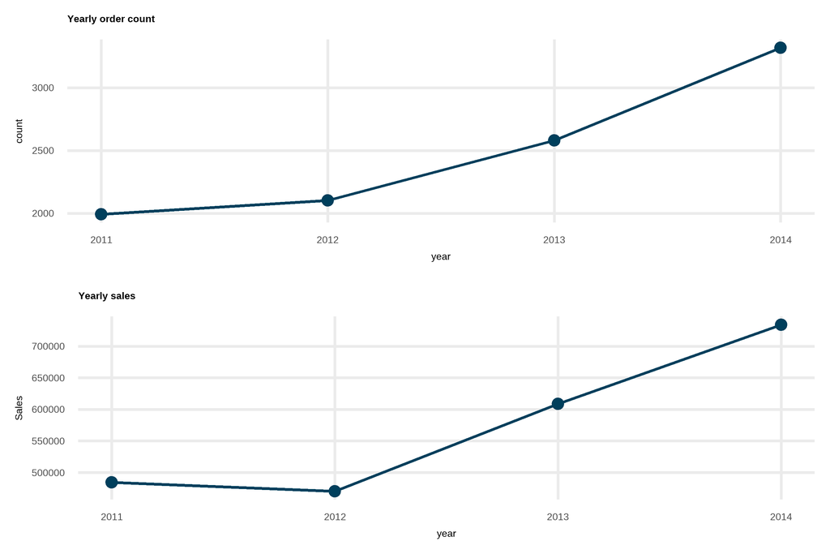

```r
yearly_orders <- data %>%
  group_by(year) %>%
  summarise(count = n())

yearly_sales <- data %>%
  group_by(year) %>%
  summarise(total_sales = sum(Sales))

# Plot
p1 <- ggplot(yearly_orders, aes(x = year, y = count)) +
  geom_line(color = "#003f5c") +
  geom_point(color = "#003f5c") +
  labs(title = "Yearly order count", y = "count")

p2 <- ggplot(yearly_sales, aes(x = year, y = total_sales)) +
  geom_line(color = "#003f5c") +
  geom_point(color = "#003f5c") +
  labs(title = "Yearly sales", y = "Sales")

gridExtra::grid.arrange(p1, p2, ncol = 1)
```

```r
yearly_sales
```

```
## # A tibble: 4 × 2
##    year total_sales
##   <dbl>       <dbl>
## 1  2011     484247.
## 2  2012     470533.
## 3  2013     608474.
## 4  2014     733947.
```

Over time, orders had increased and so are sales. However, a slight dip in sales can be observed in 2012. From 484,247 dollars total sales in 2011, Superstore sales slightly dipped to 470,532 dollars in the following year, which is a 2.83% difference or 13,715 dollars.

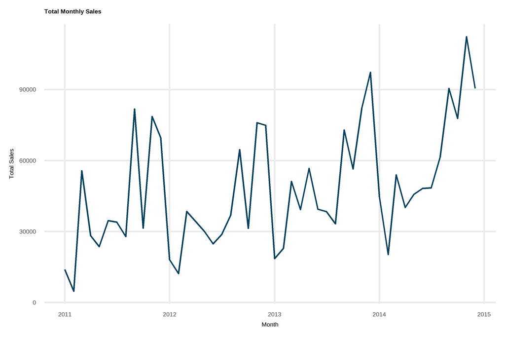

```r
monthly_sales <- data %>%
  group_by(year_month) %>%
  summarise(total_sales = sum(Sales))

ggplot(monthly_sales, aes(x = year_month, y = total_sales)) +
  geom_line(color = "#003f5c", size = 1) +
  labs(title = "Total Monthly Sales", x = "Month", y = "Total Sales")
```

Seasonal trends occurred. Superstore sales increase towards the end of the year starting in November and is sustained until December, and then drops in January. Between February and March each year, sales rise again. From April to August, a generally stable trend is evident every year. Furthermore, a sharp downward trend is observed during October.

The following provides a rough estimate of this observation:

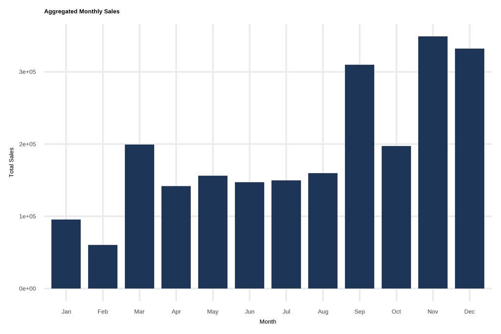

```r
monthly_agg <- data %>%
  group_by(month) %>%
  summarise(total_sales = sum(Sales))

ggplot(monthly_agg, aes(x = factor(month, labels = month.abb), y = total_sales)) +
  geom_bar(stat = "identity", fill = "#1d3557", width = 0.8) +
  labs(title = "Aggregated Monthly Sales", x = "Month", y = "Total Sales")
```

The visualization above shows total sales for each month over the course of 4 years. By magnitude, sales are higher towards the holiday seasons. Also, the academic year (opening of schools) in America usually starts in late August or early September, which can possibly explain higher sales in September of school-related products such as binders, home and office supplies, papers, bookcases, and accessories, among others (see graph below).

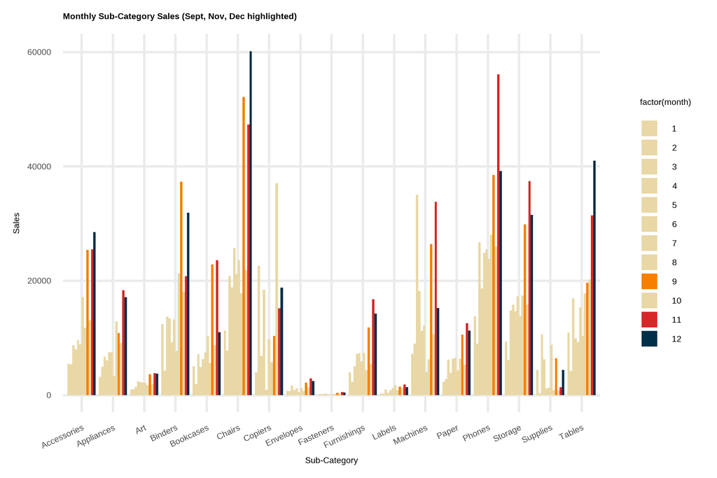

```r
month_subcat <- data %>%
  group_by(month, `Sub-Category`) %>%
  summarise(Sales = sum(Sales)) %>%
  ungroup()

# Highlight September, November, December
month_subcat <- month_subcat %>%
  mutate(highlight = ifelse(month %in% c(9, 11, 12), "highlight", "normal"))

ggplot(month_subcat, aes(x = `Sub-Category`, y = Sales, fill = factor(month))) +
  geom_bar(stat = "identity", position = "dodge") +
  scale_fill_manual(values = c(
    "#e9d8a6", "#e9d8a6", "#e9d8a6", "#e9d8a6", "#e9d8a6",
    "#e9d8a6", "#e9d8a6", "#e9d8a6", "#f77f00", "#e9d8a6",
    "#d62828", "#003049"
  )) +
  labs(
    title = "Monthly Sub-Category Sales (Sept, Nov, Dec highlighted)",
    x = "Sub-Category", y = "Sales"
  ) +
  theme(axis.text.x = element_text(angle = 25, hjust = 1))
```

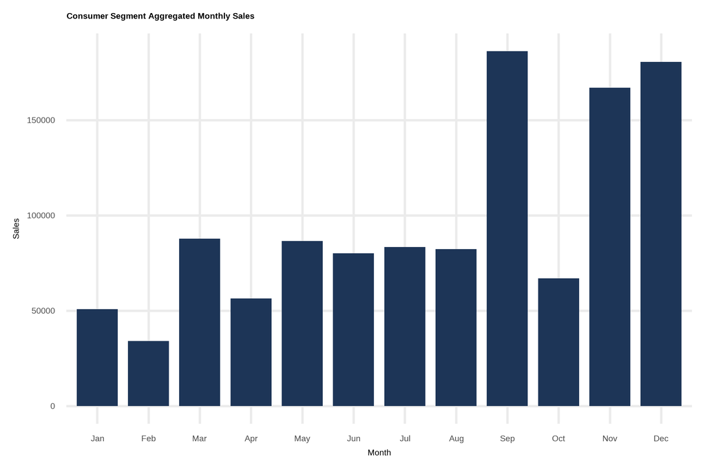

```r
consumer_monthly <- data %>%
  filter(Segment == "Consumer") %>%
  group_by(month) %>%
  summarise(Sales = sum(Sales))

ggplot(consumer_monthly, aes(x = factor(month, labels = month.abb), y = Sales)) +
  geom_bar(stat = "identity", fill = "#1d3557", width = 0.8) +
  labs(title = "Consumer Segment Aggregated Monthly Sales", x = "Month", y = "Sales")
```

Under consumer segment, sales in September, November, and December are higher than the rest of the year. This supports the possibility that increased sales in September may be due to the reopening of classes (sales of school-related products also increased).

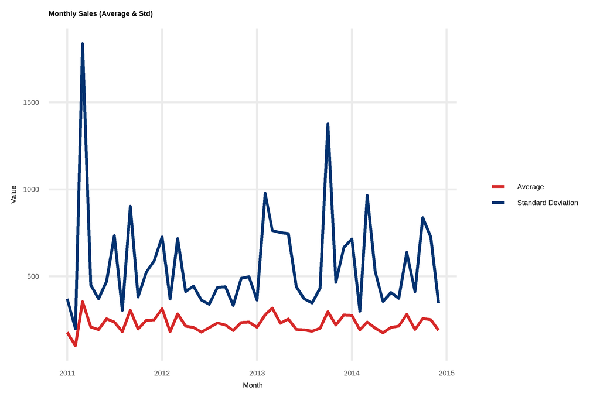

```r
monthly_stats <- data %>%
  group_by(year_month) %>%
  summarise(avg = mean(Sales), std = sd(Sales))

ggplot(monthly_stats, aes(x = year_month)) +
  geom_line(aes(y = avg, color = "Average"), size = 1.5) +
  geom_line(aes(y = std, color = "Standard Deviation"), size = 1.5) +
  labs(title = "Monthly Sales (Average & Std)", x = "Month", y = "Value") +
  scale_color_manual(values = c("Average" = "#d62828", "Standard Deviation" = "#033270")) +
  theme(legend.title = element_blank())
```

Huge variation in sales within each month can be observed throughout the period. This is confirmed by the monthly sales’ standard deviation above. Interestingly, this variation seems to have a pattern. Sales were more variable during March, and around September and October. Interestingly, from April 2012 until the end of the year, there seemed to have low variability in the sales. Along with this, the general sales trend in 2012 was slightly downward, as can be seen in the total yearly sales graph - when total yearly sales dipped a little from 2011 to 2012. On the other hand, sales were more variable in 2011, 2013, and 2014.

Store sales are typically subject to variability in sales due to a number of observable factors such as seasonality, customer behaviors, and competitive landscape, among others.

2. Seasonal trends can be observed with sales. Sales generally increase towards the end of the year - November and December (holidays) and in September (possibly due to the opening of schools. Sales under consumer segment also increased during these months. Increase in school and office supplies sales was also observed).
3. Sales had been very variable especially in March and around September and October. No significant variability was observed from April 2012, until the end of the year.

## 3.2. Product Categories

Which product categories contributed the most to the company’s sales? Which categories are underperforming, if any?

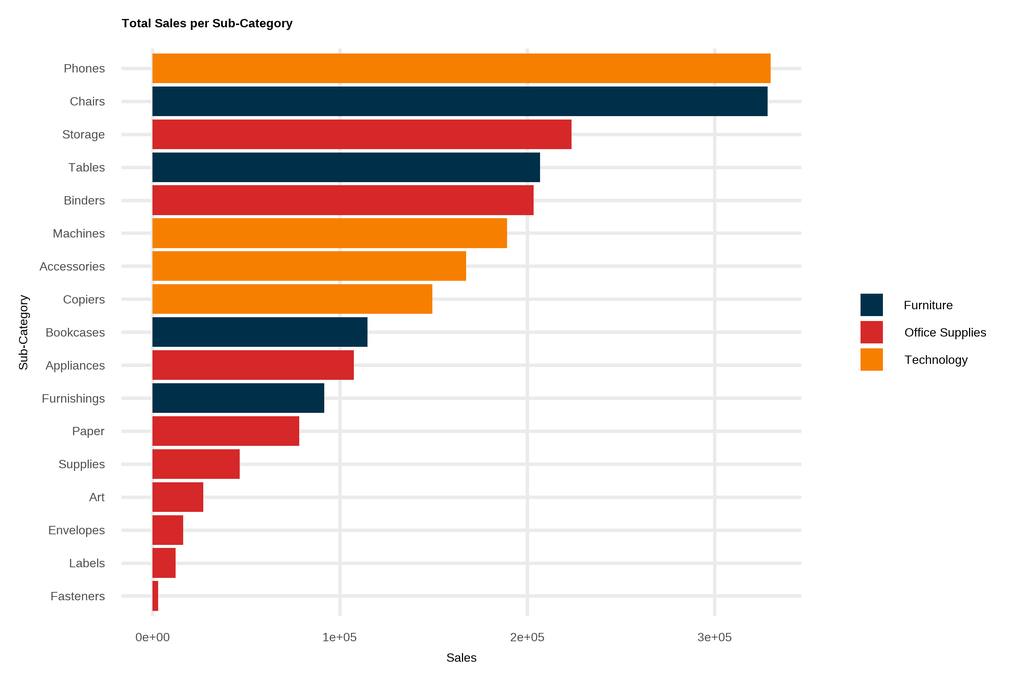

```r
df_sales <- data %>%
  group_by(Category, `Sub-Category`) %>%
  summarise(Sales = sum(Sales)) %>%
  arrange(desc(Sales))

ggplot(df_sales, aes(x = reorder(`Sub-Category`, Sales), y = Sales, fill = Category)) +
  geom_bar(stat = "identity") +
  coord_flip() +
  scale_fill_manual(values = c("#003049", "#d62828", "#f77f00")) +
  labs(title = "Total Sales per Sub-Category", x = "Sub-Category", y = "Sales") +
  theme(legend.title = element_blank())
```

The visualization above shows a general overview of the magnitude of sales for each product sub-category. For technology category, phones are the top sales-generating products. Chairs products for furniture category, and storage products for office supplies category. Throughout the 4-year period from 2011 - 2014, phones, chairs, and storage products are the three most sales-generating products. Along with them are tables, binders, and machine products.

Under the technology category, copier products are the least performing. For the furniture and office supplies category, furnishings and fasteners are the least performing.

It is worth noting that phones and chairs products sales, which are significantly higher than the rest of the sub-categories, belong to Technology and Furniture product categories, products that are generally expensive.

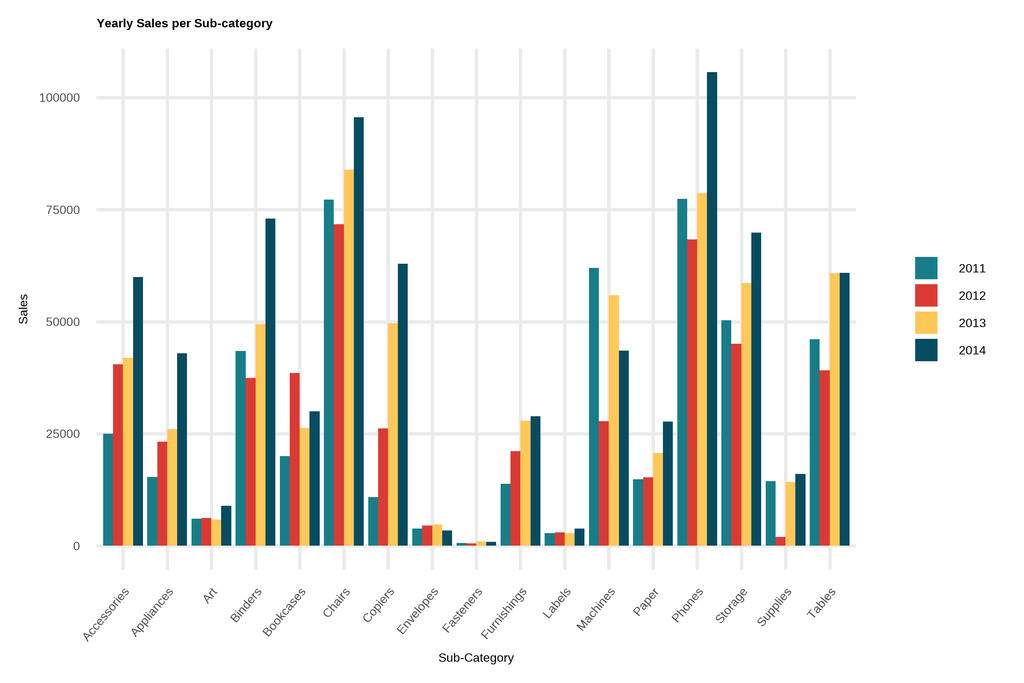

```r
yearly_sales_sub <- data %>%
  group_by(`Sub-Category`, year) %>%
  summarise(Sales = sum(Sales)) %>%
  ungroup()

ggplot(yearly_sales_sub, aes(x = `Sub-Category`, y = Sales, fill = factor(year))) +
  geom_bar(stat = "identity", position = "dodge") +
  scale_fill_manual(values = c("#177e89", "#db3a34", "#ffc857", "#084c61")) +
  labs(title = "Yearly Sales per Sub-category", x = "Sub-Category", y = "Sales") +
  theme(
    axis.text.x = element_text(angle = 50, hjust = 1),
    legend.title = element_blank()
  )
```

Shown is how sales on different products had changed over the 4-year period. For some product categories, sales had been fastest growing in 2014. This was not the case for bookcases, machines, supplies, and tables, which all saw a slow growth in sales in the same year. In 2012, products under binders, phones, storages, supplies, and tables experienced negative growth in sales, especially machine products.

```r
yearly_growth <- yearly_sales_sub %>%
  group_by(`Sub-Category`) %>%
  mutate(yearly_growth_rate = (Sales / lag(Sales) - 1) * 100) %>%
  summarise(yearly_growth_rate = mean(yearly_growth_rate, na.rm = TRUE)) %>%
  arrange(desc(yearly_growth_rate))

yearly_growth
```

```
## # A tibble: 17 × 2
##    `Sub-Category` yearly_growth_rate
##    <chr>                       <dbl>
##  1 Supplies                   186.
##  2 Copiers                     85.9
##  3 Appliances                  42.9
##  4 Accessories                 36.2
##  5 Furnishings                 29.5
##  6 Bookcases                   24.9
##  7 Paper                       24.1
##  8 Binders                     21.9
##  9 Art                         16.2
## 10 Fasteners                   16.0
## 11 Tables                      13.5
## 12 Storage                     12.9
## 13 Phones                      12.6
## 14 Labels                      12.1
## 15 Machines                     8.01
## 16 Chairs                       7.91
## 17 Envelopes                   -2.24
```

By average sales annual growth rate, envelope products had been the slowest while supplies products had been the fastest at 185% annual average growth rate (AAGR), followed by copier and appliances products at 86% and 43% AAGR, respectively.

**Key Findings:** 1. During the 4-year period, phones generated the most sales under the technology category, chairs for the furniture category, and storage products for office supplies category. These three are followed by tables, binders, and machine products. On the other hand, copiers, furnishings, and fasteners are the least sales-generating products under the technology, furniture, and office supplies category, respectively.

## 3.3. Geographic Insights

How does sales performance vary across the regions? Are there promising geographical regions or areas requiring improved marketing?

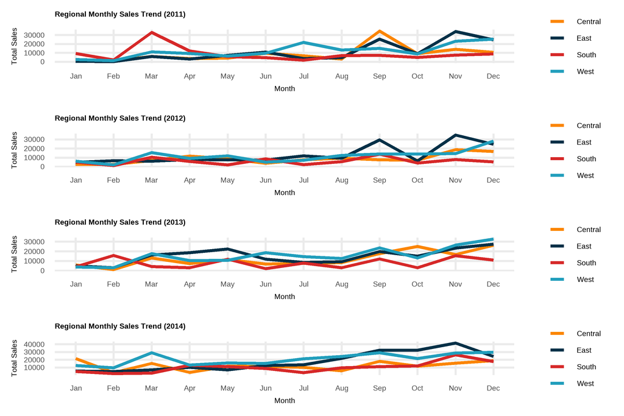

```r
# Prepare data for each year
years <- 2011:2014
plots <- list()

for (y in years) {
  df <- data %>%
    filter(year == y) %>%
    group_by(Region, month) %>%
    summarise(Sales = sum(Sales)) %>%
    ungroup()

  p <- ggplot(df, aes(x = month, y = Sales, color = Region)) +
    geom_line(size = 1.5) +
    scale_color_manual(values = c(
      "Central" = "#fb8500", "South" = "#d62828",
      "West" = "#219ebc", "East" = "#023047"
    )) +
    labs(
      title = paste("Regional Monthly Sales Trend (", y, ")", sep = ""),
      x = "Month", y = "Total Sales"
    ) +
    scale_x_continuous(breaks = 1:12, labels = month.abb) +
    theme(legend.title = element_blank())

  plots[[as.character(y)]] <- p
}

gridExtra::grid.arrange(grobs = plots, ncol = 1)
```

As shown before, seasonal trend occurred, with sales increasing in holidays (November and December), opening of classes (September), and possibly Easter (March). This is also the case with regional sales data per year. Total sales has been generally higher most of the year in the West, followed by the East compared to the remaining two regions. Sales in the South has been lower each year compared to other regions with the exception in March 2011 when sales in the South was more than thrice the next best performer.

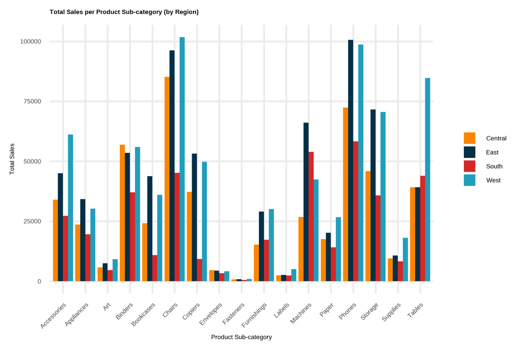

```r
reg_sub <- data %>%
  group_by(Region, `Sub-Category`) %>%
  summarise(Sales = sum(Sales)) %>%
  ungroup()

ggplot(reg_sub, aes(x = `Sub-Category`, y = Sales, fill = Region)) +
  geom_bar(stat = "identity", position = "dodge") +
  scale_fill_manual(values = c(
    "Central" = "#fb8500", "South" = "#d62828",
    "West" = "#219ebc", "East" = "#023047"
  )) +
  labs(
    title = "Total Sales per Product Sub-category (by Region)",
    x = "Product Sub-category", y = "Total Sales"
  ) +
  theme(
    axis.text.x = element_text(angle = 45, hjust = 1),
    legend.title = element_blank()
  )
```

Take note that this sales refer to total sales from 2011 - 2014 in each region, which does not show how sales behaved throughout the years. This visualization rather intends to show a rough estimate of the magnitude of sales for different products in each region.

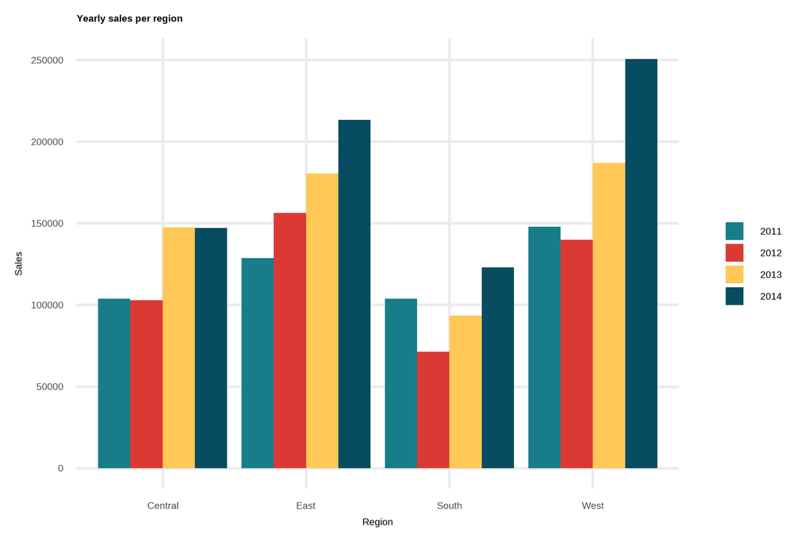

```r
year_s <- data %>%
  group_by(Region, year) %>%
  summarise(Sales = sum(Sales)) %>%
  ungroup()

ggplot(year_s, aes(x = Region, y = Sales, fill = factor(year))) +
  geom_bar(stat = "identity", position = "dodge") +
  scale_fill_manual(values = c("#177e89", "#db3a34", "#ffc857", "#084c61")) +
  labs(title = "Yearly sales per region", x = "Region", y = "Sales") +
  theme(legend.title = element_blank())
```

Shown is how sales for each region changed over time. In the Central region, a sharp positive growth was observed from 2013, while yearly positive growth was consistent in the East. For the South region, a negative growth was observed in 2012, but the region rebounded thereafter. Similarly for the West, negative growth was observed in 2012, but rebounded and sustained positive growth thereafter.

It was observed that there was a slight dip in total sales in 2012. From the visualization above, it can be inferred that South had contributed the most to that dip, followed by the West and then the Central. Interestingly, the East region still grew positively in 2012.

```r
year_s_growth <- year_s %>%
  group_by(Region) %>%
  mutate(yearly_growth_rate = (Sales / lag(Sales) - 1) * 100) %>%
  summarise(yearly_growth_rate = mean(yearly_growth_rate, na.rm = TRUE)) %>%
  ungroup()

year_s_growth
```

```
## # A tibble: 4 × 2
##   Region  yearly_growth_rate
##   <chr>                <dbl>
## 1 Central               14.1
## 2 East                  18.4
## 3 South                 10.4
## 4 West                  20.8
```

Using the Sales Average Annual Growth Rate (AAGR) of each region for the 4-year period, we see that the West had been the fastest growing Region in terms of sales, followed by the East, and then the Central region, and then South. Further investigation can be done to understand possible factors that may affect the differences which include economic factor, market conditions (saturation), consumer preference, among others.

*Average Annual Growth Rate (AAGR) is calculated by getting the arithmetic mean of the yearly growth rates*

**Key Findings:** 1. Seasonal trend was also present within each region. For all, sales generally increase towards the end of the year - November and December. Significant increase also happened in September, which can be attributed to the opening of classes. One thing to support this is the increased sales of school-related products and the increased sales under consumer segment during September. Monthly sales has been higher most of the year in the West followed by the East, compared to the remaining two regions. Sales in the South has been lower most of each year compared to other regions with the exception in March 2011 when sales in the South was more than thrice the next best performer.

## 3.4. Profitability

Which products are more profitable and which were not? With the available data, what factors affected the company’s profit? How is the company’s profitability during the period?

```r
yearly_summary <- data %>%
  group_by(year) %>%
  summarise(
    Sales = sum(Sales),
    net_profit = sum(net_profit)
  ) %>%
  mutate(profit_margin = (net_profit / Sales) * 100)

yearly_summary
```

```
## # A tibble: 4 × 4
##    year   Sales net_profit profit_margin
##   <dbl>   <dbl>      <dbl>         <dbl>
## 1  2011 484247.     49544.          10.2
## 2  2012 470533.     61619.          13.1
## 3  2013 608474.     81727.          13.4
## 4  2014 733947.     93508.          12.7
```

Using profit margin, the company had generated the least profit in 2011 at 10.2311%. After a year, 2012, the company generated relatively higher profit at 13.0955% margin. This continued and the company registered a higher profit margin in 2013 at 13.4315%. The trend, however, slowed down and the company generated a lower profit margin at 12.7404%, even lower than that of 2012.

*While profit margin is a good metric, it is not the only metric to understand the financial performance of the company. However, since this dataset primarily contains sales data and is not a comprehensive company data (does not include data on Cost of Goods Sold (COGS), shareholder’s equity, operating income, etc.) the analysis will make use of profit margin.*

```r
profit_margin_df <- data %>%
  group_by(Category, `Sub-Category`) %>%
  summarise(profit_margin = mean(profit_margin, na.rm = TRUE)) %>%
  ungroup()

profit_margin_df
```

```
## # A tibble: 17 × 3
##    Category        `Sub-Category` profit_margin
##    <chr>           <chr>                  <dbl>
##  1 Furniture       Bookcases             -12.7
##  2 Furniture       Chairs                  4.39
##  3 Furniture       Furnishings            13.7
##  4 Furniture       Tables                -14.8
##  5 Office Supplies Appliances            -15.7
##  6 Office Supplies Art                    25.2
##  7 Office Supplies Binders               -20.0
##  8 Office Supplies Envelopes              42.3
##  9 Office Supplies Fasteners              29.9
## 10 Office Supplies Labels                 43.0
## 11 Office Supplies Paper                  42.6
## 12 Office Supplies Storage                 8.91
## 13 Office Supplies Supplies               11.2
## 14 Technology      Accessories            21.8
## 15 Technology      Copiers                31.7
## 16 Technology      Machines               -7.20
## 17 Technology      Phones                 11.9
```

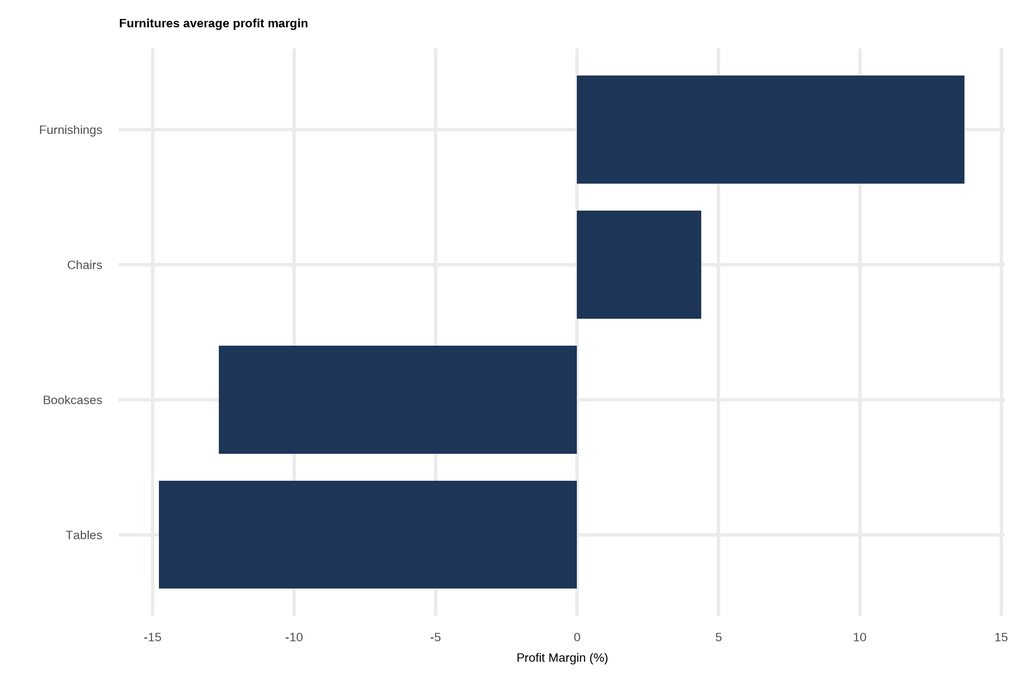

```r
furniture_profit <- profit_margin_df %>%
  filter(Category == "Furniture") %>%
  select(`Sub-Category`, profit_margin)

ggplot(furniture_profit, aes(x = profit_margin, y = reorder(`Sub-Category`, profit_margin))) +
  geom_bar(stat = "identity", fill = "#1d3557", width = 0.8) +
  labs(title = "Furnitures average profit margin", x = "Profit Margin (%)", y = "")
```

For furniture products, furnishings products, on average, are the most profitable followed by chairs products. On the other hand, the company was operating at a loss on tables and bookcases products. Assuming similar sales, loss on tables are higher than gains on furnishings.

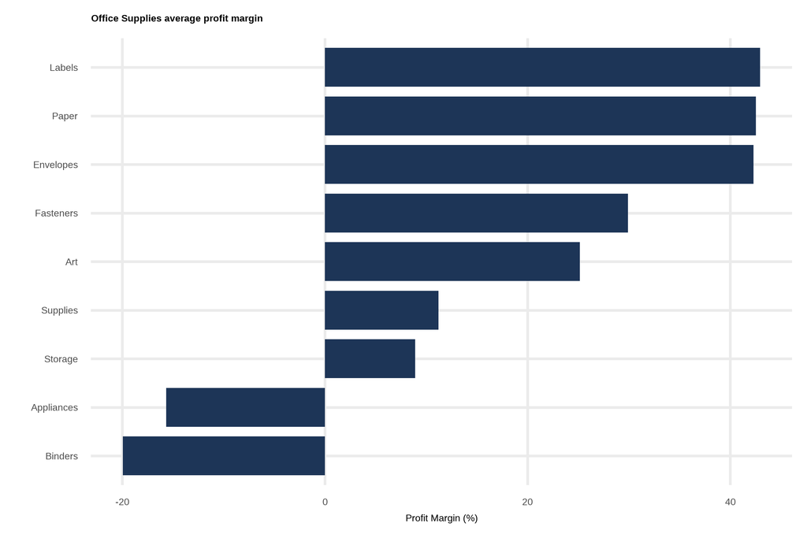

```r
office_profit <- profit_margin_df %>%
  filter(Category == "Office Supplies") %>%
  select(`Sub-Category`, profit_margin)

ggplot(office_profit, aes(x = profit_margin, y = reorder(`Sub-Category`, profit_margin))) +
  geom_bar(stat = "identity", fill = "#1d3557", width = 0.8) +
  labs(title = "Office Supplies average profit margin", x = "Profit Margin (%)", y = "")
```

For office supplies, average profit margins vary widely. Labels, paper, envelopes, and fasteners have high profit margins (around 30-43%), while binders, appliances, and storage have lower or negative margins. Binders show the highest loss on average.

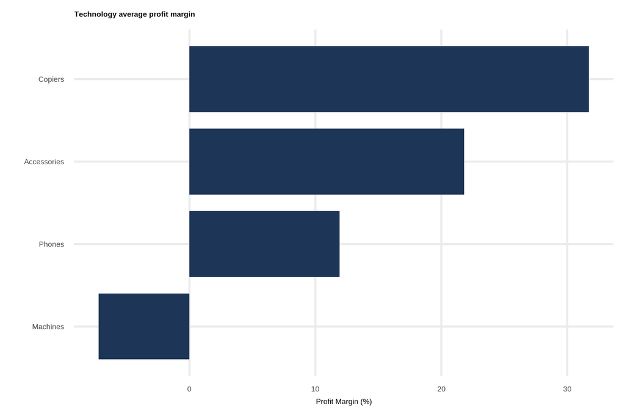

```r
tech_profit <- profit_margin_df %>%
  filter(Category == "Technology") %>%
  select(`Sub-Category`, profit_margin)

ggplot(tech_profit, aes(x = profit_margin, y = reorder(`Sub-Category`, profit_margin))) +
  geom_bar(stat = "identity", fill = "#1d3557", width = 0.8) +
  labs(title = "Technology average profit margin", x = "Profit Margin (%)", y = "")
```

On technology products, the company, on average, was profiting more compared to furniture ones. Three of its product sub-categories were generating profit at much higher margin profit: 12% for phones, 22% for tech accessories, and 32% profit margin for copiers products. The company, on the other hand, machines products, was operating at a loss with machine products.

# Conclusion

Based on the exploratory data analysis, we have gained several insights into the Superstore’s sales and profitability.

# Recommendations

1. **Focus on High-Performing Products**: Invest in marketing and inventory for phones, chairs, storage, and other top-selling categories. Consider discontinuing or reevaluating underperforming products like copiers, furnishings, and fasteners.
2. **Optimize Pricing and Discounts**: Analyze the impact of discounts on profitability. Consider reducing discounts on loss-making products like tables and bookcases. Implement dynamic pricing strategies.
3. **Regional Strategies**: Develop targeted marketing campaigns for the South and Central regions to boost sales. Leverage the strong performance in the West and East as benchmarks. Consider opening new stores or expanding operations in high-growth regions.
4. **Seasonal Planning**: Prepare for seasonal sales peaks by increasing inventory and staffing during November, December, and September. Use historical data to forecast demand and optimize supply chain.
5. **Product Mix Optimization**: Re-evaluate the product mix to emphasize high-margin items like furnishings, copiers, and labels. Consider phasing out or repositioning low-margin products.
6. **Invest in Technology**: Leverage data analytics to continuously monitor sales and profitability. Implement a dashboard for real-time performance tracking.

# References

- Kaggle Superstore Sales Dataset: https://www.kaggle.com/datasets/ishanshrivastava28/superstore-sales
- R packages: readxl, dplyr, tidyr, lubridate, ggplot2, scales, knitr, gridExtra.